```python
import os

import folium
import geojson
import matplotlib.pyplot as plt
import numpy as np
import pandas as pd
import pickle
import plotly.express as px
import plotly.graph_objects as go
import re
import requests
import seaborn as sns

from folium import plugins
from folium.plugins import HeatMap
from matplotlib.ticker import FuncFormatter, MultipleLocator
from scipy import stats
from plotly.subplots import make_subplots

earth_tone_colors = ['#2e4460', '#7a8c5c', '#9e6b1e', '#cc5e42', '#5a6e40', '#c8a96e', '#b8724e', '#3d6b6b', '#e8d8c4', '#ecddd0']
sns.set_theme()
```

# New York City Rent and Salary

## Motivation

> 1. What is your dataset?
> 2. Why did you choose this/these particular dataset(s)?
> 3. What was your goal for the end user's experience?
1. Our project draws on two primary datasets. The first is the [NYC OpenData Citywide Payroll Data (Fiscal Year)](https://data.cityofnewyork.us/City-Government/Citywide-Payroll-Data-Fiscal-Year-/k397-673e/about_data) dataset,a comprehensive public record maintained by New York City’s Office of Payroll Administration. It contains annual compensation data for city employees across agencies and departments, including base salary, overtime pay, total earnings, job title, agency, borough of employment, and fiscal year. Spanning more than a decade of records, the dataset offers a detailed view of how New York City’s public workforce is compensated over time. The second dataset is the [StreetEasy Rent Index](https://streeteasy.com/blog/data-dashboard/?agg=Total&metric=Inventory&type=Rentals&bedrooms=Any%20Bedrooms&property=Any%20Property%20Type&minDate=2010-01-01&maxDate=2026-03-01&area=NYC,Brooklyn), which tracks rental prices across New York City’s five boroughs, using median and average rent values over multiple years. This housing data provides the broader economic context needed to understand what those salaries actually mean in practice — particularly in a city where housing costs dominate household expenses.

## Basic Stats

> 1. Write about your choices in data cleaning and preprocessing
> 2. Write a short section that discusses the dataset stats, containing key points/plots from your exploratory data analysis.
1. The raw NYC Citywide Payroll dataset contains 6,775,830 records and 17 variables, totaling approximately 1.22 GB of data. Before analysis, we performed several cleaning steps to make the dataset consistent and usable. We removed duplicate entries and ensured that salary-related fields were correctly formatted as numeric values. We also checked for missing or inconsistent values and standardized borough names to ensure alignment across datasets. For example, “RICHMOND” was renamed to “Staten Island” to match the naming convention used in the rent dataset. This step was important for accurately comparing payroll and housing data across boroughs.
2. The exploratory analysis of the payroll dataset shows a wide distribution of employee earnings, reflecting the diversity of roles within New York City’s workforce. Total compensation varies significantly depending on job title, agency, and the use of overtime pay. We also observed clear differences across boroughs, both in workforce distribution and average earnings. In the rent dataset, housing costs show a steady upward trend across all five boroughs over time, with some boroughs consistently remaining more expensive than others. When visualizing both datasets together, a clear gap emerges, while salaries increase gradually for some roles, rent prices rise more consistently, suggesting growing pressure on public employees. Overtime pay also plays an important role in increasing total income for certain groups, which is reflected in the wider spread of earnings shown in the payroll distribution plots.

### Rent datasets

The rent datasets were 198x198 rows and columns. The first column contained areName, the second Borough, and the third areaType. The rest contained median asking rent for each area from Januar 2010 to December 2025. One contained the median rent for all apartment types across the areas, while the others had median rent per are for studio, one-bedroom, two-bedroom and three plus bedroom apartments.

They were loaded, and as the area NYC had NaN as its borough, it was set to New York City.

```python
median = pd.read_csv('data/medianAskingRent_All/medianAskingRent_All.csv')
studio = pd.read_csv('data/medianAskingRent_Studio/medianAskingRent_Studio.csv')
studio['Borough'] = studio['Borough'].fillna('New York City')
onebd = pd.read_csv('data/medianAskingRent_OneBd/medianAskingRent_OneBd.csv')
onebd['Borough'] = onebd['Borough'].fillna('New York City')
twobd = pd.read_csv('data/medianAskingRent_TwoBd/medianAskingRent_TwoBd.csv')
twobd['Borough'] = twobd['Borough'].fillna('New York City')
threeplusbd = pd.read_csv('data/medianAskingRent_ThreePlusBd/medianAskingRent_ThreePlusBd.csv')
threeplusbd['Borough'] = threeplusbd['Borough'].fillna('New York City')
```

Before deciding how to calculate the mean rent for each apartment type, we looked into the difference in the cheapest and most expensive apartment for each size, to see if it was possible to just find one median for all boroughs.

```python
prices = {}
max_dif = 0
when = 'x'
where = []
test = onebd[onebd['Borough']=='Queens']
for period in list(onebd.keys())[51:-3]:
    min_price = test[period].min()
    max_price = test[period].max()
    dif = max_price-min_price
    mean_price = test[period].mean()
    std_price = test[period].std()
    median_price = test[period].median()
    prices[period] = {'Min': min_price,
                      'Max': max_price,
                      'Difference': dif,
                      'Mean': mean_price,
                      'Std': std_price,
                      'Median': median_price}
    if dif > max_dif:
        max_dif = dif
        when = period
        where = [test[test[period]==min_price]['areaName'],test[test[period]==max_price]['areaName']]
```

```python
max_dif, when, where
```

```
(np.float64(2323.5),
 '2025-01',
 [157     Rockaway All
  176    The Rockaways
  Name: areaName, dtype: object,
  105    Long Island City
  Name: areaName, dtype: object])
```

```python
prices['2025-02']
```

```
{'Min': np.float64(1996.5),
 'Max': np.float64(4087.5),
 'Difference': np.float64(2091.0),
 'Mean': np.float64(2476.04),
 'Std': np.float64(435.9254265353193),
 'Median': np.float64(2400.0)}
```

The differences were deemed too large so the mean was found for each borough for each apartment type.

We then made a plot to see the change in rent through the years, and plots to see the distribution of rent by apartment size

```python
datasets = {
    "All": median,
    "One bedroom": onebd,
    "Two bedrooms": twobd,
    "Three plus bedrooms": threeplusbd,
    "Studio": studio
}

def get_month_cols(df):
    return [c for c in df.columns if len(c) == 7 and c[4] == "-" and c[:4].isdigit() and c[5:].isdigit()]

def prep_df(df):
    out = df.copy()
    if "Borough" in out.columns:
        out["Borough"] = out["Borough"].fillna("New York City")
    return out

for k in datasets:
    datasets[k] = prep_df(datasets[k])
```

```python
month_cols = get_month_cols(datasets["All"])

# Borough-level median per month (across all areas in each borough)
borough_medians = (
    datasets["All"]
    .groupby("Borough")[month_cols]
    .median(numeric_only=True)
    .reset_index()
)

borough_medians_long = borough_medians.melt(
    id_vars="Borough",
    var_name="Month",
    value_name="MedianRent"
).dropna()

borough_medians_long["Month"] = pd.to_datetime(borough_medians_long["Month"])

fig_borough = px.line(
    borough_medians_long,
    x="Month",
    y="MedianRent",
    color="Borough",
    title="Median Asking Rent by Borough Over Time (All Apartment Types)",
    labels={"MedianRent": "Median Asking Rent (USD)", "Month": "Date"},
    template="plotly_white"
)

fig_borough.update_layout(
    hovermode="x unified",
    legend_title_text="Borough",
    xaxis_title="Date",
    yaxis_title="Median Asking Rent (USD)"
)

fig_borough.show()
```

```python
# Build one long dataframe with all observations from all months and all areas
dist_frames = []
for apt_type, df in {
    "One bedroom": datasets["One bedroom"],
    "Two bedrooms": datasets["Two bedrooms"],
    "Three plus bedrooms": datasets["Three plus bedrooms"],
    "Studio": datasets["Studio"]
}.items():
    mcols = get_month_cols(df)
    tmp = df[["Borough"] + mcols].melt(
        id_vars="Borough",
        var_name="Month",
        value_name="Rent"
    )
    tmp["ApartmentType"] = apt_type
    dist_frames.append(tmp)

dist_df = pd.concat(dist_frames, ignore_index=True).dropna(subset=["Rent"])
dist_df["Month"] = pd.to_datetime(dist_df["Month"])

# Histogram + KDE-like shape via marginal violin
fig_hist = px.histogram(
    dist_df,
    x="Rent",
    color="ApartmentType",
    facet_col="ApartmentType",
    facet_col_wrap=2,
    nbins=50,
    opacity=0.65,
    marginal="violin",
    title="Rent Distributions by Apartment Type",
    labels={"Rent": "Monthly Asking Rent (USD)", "ApartmentType": "Apartment Type"},
    template="plotly_white"
)
fig_hist.for_each_annotation(lambda a: a.update(text=a.text.split("=")[-1]))
fig_hist.update_layout(showlegend=False)
fig_hist.show()

# Box plot for robust summary (median, IQR, outliers)
fig_box = px.box(
    dist_df,
    x="ApartmentType",
    y="Rent",
    color="ApartmentType",
    points="outliers",
    title="Box Plot of Rents by Apartment Type",
    labels={"Rent": "Monthly Asking Rent (USD)", "ApartmentType": "Apartment Type"},
    template="plotly_white"
)
fig_box.update_layout(showlegend=False)
fig_box.show()

# Optional: distribution by borough within each apartment type
fig_violin_borough = px.violin(
    dist_df,
    x="Borough",
    y="Rent",
    color="Borough",
    facet_col="ApartmentType",
    facet_col_wrap=2,
    box=True,
    points=False,
    title="Rent Distributions by Borough and Apartment Type",
    template="plotly_white"
)
fig_violin_borough.for_each_annotation(lambda a: a.update(text=a.text.split("=")[-1]))
fig_violin_borough.update_layout(showlegend=False)
fig_violin_borough.show()
```

From this we could see that Manhattan had higher rents across all apartment types, and that it's mostly two-bedroom apartments that were put up for rent.

After this the necessary keys, for comparing the rent data to the income data, was collected. As areaType wasn't needed, it was discarded. Data from before 2014 was also discarded, as the income data doesn't go back any further.

```python
keys = list(onebd.keys())
years = keys[51:-3]
area_info = [keys[1]]
old_keys = area_info + years
new_keys = ['apartmentType'] + old_keys
```

Then a new dataframe was made, to store the average rent for each area for each apartment type.

```python
df_new = pd.DataFrame(columns=new_keys)
og_dfs = [onebd, twobd, threeplusbd, studio]
types = ['One bedroom', 'Two bedrooms', 'Three plus bedrooms', 'Studio']
boroughs = list(og_dfs[0]['Borough'].unique())

for i in range(len(og_dfs)):
    df = og_dfs[i][old_keys]
    for borough in boroughs:
        df_means = list(df[df['Borough']==borough][years].mean())
        new_info = [ types[i]] + [borough] + df_means
        df_new.loc[len(df_new)] = new_info

df_new = df_new.round(2)
# df_new.to_csv('data/mean_rents.csv',index=False)
```

The same was done with all the years

```python
keys = list(onebd.keys())
years = keys[3:-3]
area_info = [keys[1]]
old_keys = area_info + years
new_keys = ['apartmentType'] + old_keys

df_new = pd.DataFrame(columns=new_keys)
og_dfs = [onebd, twobd, threeplusbd, studio]
types = ['One bedroom', 'Two bedrooms', 'Three plus bedrooms', 'Studio']
boroughs = list(og_dfs[0]['Borough'].unique())

for i in range(len(og_dfs)):
    df = og_dfs[i][old_keys]
    for borough in boroughs:
        df_means = list(df[df['Borough']==borough][years].mean())
        new_info = [ types[i]] + [borough] + df_means
        df_new.loc[len(df_new)] = new_info

df_new = df_new.round(2)
# df_new.to_csv('data/mean_rents_all_years.csv',index=False)
```

As we wanted to compare to the population in NYC as well, another dataframe was made, that contained apartmentType, Borough, areaName, and rent info from all years.

```python
# Create new dataframe with areaName, Borough, apartmentType, and years
df_rent_by_area = pd.DataFrame(columns=['apartmentType', 'Borough', 'areaName'] + years)

# For each apartment type
for i in range(len(og_dfs)):
    df = og_dfs[i]
    apt_type = types[i]

    # Get unique areaNames in this dataframe
    area_names = df['areaName'].unique()

    # For each areaName
    for area in area_names:
        area_df = df[df['areaName'] == area]

        if len(area_df) > 0:
            # Get the borough for this area (should be consistent)
            borough = area_df['Borough'].iloc[0]

            # Get means across years
            area_means = list(area_df[years].mean())

            # Add row
            new_row = [apt_type, borough, area] + area_means
            df_rent_by_area.loc[len(df_rent_by_area)] = new_row

df_rent_by_area = df_rent_by_area.round(2)
# df_rent_by_area.to_csv('data/mean_rents_by_area.csv', index=False)
```

### Salary data

After loading the payroll data, a fair amount of data cleaning and preprocessing was done. Boroughs were made the same case, and boroughs that were not the main five boroughs of NYC, were removed. Then dollar signs and comma-separators were removed from all money-related fields.

```python
cwpd = pd.read_csv('data/Citywide_Payroll_Data_(Fiscal_Year)_20260506.csv')
cwpd_raw = cwpd.copy()

cwpd['Work Location Borough'] = cwpd['Work Location Borough'].str.upper()
cwpd = cwpd[cwpd["Work Location Borough"].isin(['MANHATTAN', 'BROOKLYN', 'QUEENS', 'BRONX', 'RICHMOND'])]

for c in ["Base Salary", "Regular Hours", "Regular Gross Paid", "OT Hours", "Total OT Paid", "Total Other Pay"]:
    cwpd[c] = cwpd[c].replace("[$,]","", regex=True).apply(pd.to_numeric)
```

The raw dataset size and length was calculated.

```python
print(os.path.getsize("data/Citywide_Payroll_Data_(Fiscal_Year)_20260506.csv") / 1000000)
print(len(cwpd_raw))
```

```
1222.331076
6775830
```

Entries with negative regular hours and regular gross pay less than $20k were removed, as these were either people who were probably paid too much by error (and thus had to pay back), or in the case of low gross pay, not regular jobs.

An hourly rate and annual salary estimate was calculated, to make comparison between people with different pay bases easier. Then boroughs were renamed again, to match up with the StreetEasy Rent Index dataset.

```python
cwpd = cwpd[cwpd["Regular Hours"] >= 0]
cwpd = cwpd[cwpd["Regular Gross Paid"] > 20000]

cwpd["Hourly Rate"] = cwpd["Regular Gross Paid"] / np.where(cwpd["Regular Hours"] == 0, 2080, cwpd["Regular Hours"])
cwpd["Annual Salary Estimate"] = cwpd["Hourly Rate"] * 52 * 5 * 8 # Working 8 hours/day, 5 days/week, 52 weeks/year

cwpd = cwpd.replace({'MANHATTAN': 'Manhattan',
                         'QUEENS': 'Queens',
                         'BROOKLYN': 'Brooklyn',
                         'BRONX': 'Bronx',
                         'RICHMOND': 'Staten Island'
                         }, regex=True)
```

A quick look at the head of the cleaned dataset can be seen here:

```python
cwpd.head()
```

|  | Fiscal Year | Payroll Number | Agency Name | Last Name | First Name | Mid Init | Agency Start Date | Work Location Borough | Title Description | Leave Status as of June 30 | Base Salary | Pay Basis | Regular Hours | Regular Gross Paid | OT Hours | Total OT Paid | Total Other Pay | Hourly Rate | Annual Salary Estimate |
| --- | --- | --- | --- | --- | --- | --- | --- | --- | --- | --- | --- | --- | --- | --- | --- | --- | --- | --- | --- |
| 0 | 2025 | 67.0 | ADMIN FOR CHILDREN'S SVCS | BLANCO | ELMER | S | 02/04/2013 | Manhattan | PROGRAM EVALUATOR | ACTIVE | 95897.0 | per Annum | 1820.0 | 89097.13 | 0.00 | 0.00 | 699.41 | 48.954467 | 101825.291429 |
| 1 | 2025 | 67.0 | ADMIN FOR CHILDREN'S SVCS | OTERO | MATTHEW | P | 02/22/2011 | Bronx | CHILD PROTECTIVE SPECIALIST SUPERVISOR | ACTIVE | 100050.0 | per Annum | 1820.0 | 96959.10 | 73.00 | 4291.75 | 6935.28 | 53.274231 | 110810.400000 |
| 2 | 2025 | 67.0 | ADMIN FOR CHILDREN'S SVCS | PASCALL | DERRICK | F | 02/22/2011 | Manhattan | CHILD PROTECTIVE SPECIALIST SUPERVISOR | ACTIVE | 106346.0 | per Annum | 1820.0 | 100503.13 | 0.00 | 0.00 | 732.41 | 55.221500 | 114860.720000 |
| 3 | 2025 | 67.0 | ADMIN FOR CHILDREN'S SVCS | DAUCHER | MEGHAN | B | 02/28/2011 | Manhattan | AGENCY ATTORNEY | ACTIVE | 127802.0 | per Annum | 1820.0 | 82894.55 | 0.00 | 0.00 | 9804.97 | 45.546456 | 94736.628571 |
| 4 | 2025 | 67.0 | ADMIN FOR CHILDREN'S SVCS | JENKINS | LAMAR | T | 06/03/2024 | Bronx | SPECIAL OFFICER | ACTIVE | 39206.0 | per Annum | 2080.0 | 37769.10 | 354.75 | 10000.28 | 7737.53 | 18.158221 | 37769.100000 |

A few of the key values were looked at with simple summaries and plots. First, the amount of entries for each of the boroughs (which shows a large disproportion, with Manhattan having substantially more):

```python
cwpd["Work Location Borough"].value_counts()
```

```
Work Location Borough
Manhattan        2347932
Queens            521862
Brooklyn          454078
Bronx             241066
Staten Island      69167
Name: count, dtype: int64
```

Then some summary statistics about the calculated annual salary estimate:

```python
cwpd[cwpd["Annual Salary Estimate"] > 20000][["Fiscal Year", "Annual Salary Estimate"]].groupby("Fiscal Year").describe()
```

| Fiscal Year | Annual Salary Estimate count | Annual Salary Estimate mean | Annual Salary Estimate std | Annual Salary Estimate min | Annual Salary Estimate 25% | Annual Salary Estimate 50% | Annual Salary Estimate 75% | Annual Salary Estimate max |
| --- | --- | --- | --- | --- | --- | --- | --- | --- |
| 2014 | 2890.0 | 79951.503769 | 42601.037810 | 26791.082397 | 48255.830935 | 69697.107288 | 94315.625425 | 5.055928e+05 |
| 2015 | 303806.0 | 73277.065637 | 228461.039162 | 20000.050000 | 44122.423647 | 68415.400210 | 82136.942500 | 5.489282e+07 |
| 2016 | 313863.0 | 76305.731279 | 266274.422173 | 20000.190000 | 45136.612398 | 67909.726776 | 86727.473966 | 6.409226e+07 |
| 2017 | 328303.0 | 81706.443434 | 278888.634121 | 20000.140000 | 47482.137425 | 70993.870000 | 93127.902685 | 6.127806e+07 |
| 2018 | 334277.0 | 80811.584769 | 293736.824442 | 20002.030000 | 47077.395307 | 71634.084821 | 91552.383708 | 7.743273e+07 |
| 2019 | 340915.0 | 83990.103411 | 236334.436709 | 20000.270000 | 48688.598667 | 74978.255781 | 99519.920000 | 6.173920e+07 |
| 2020 | 336753.0 | 83261.596227 | 271481.119654 | 20001.040000 | 49504.468571 | 75560.460000 | 96798.110000 | 8.861402e+07 |
| 2021 | 329614.0 | 85809.264303 | 215667.219136 | 20000.030000 | 50107.600000 | 79034.913571 | 98967.526888 | 6.193949e+07 |
| 2022 | 335527.0 | 87528.429683 | 238702.459392 | 20000.020000 | 48679.410000 | 79626.290000 | 105418.080000 | 6.199411e+07 |
| 2023 | 328879.0 | 88485.730508 | 228550.155709 | 20000.410000 | 50065.105000 | 82129.320000 | 104131.920000 | 6.193949e+07 |
| 2024 | 338755.0 | 97665.549967 | 300847.244795 | 20000.090000 | 53949.600714 | 85896.365714 | 117874.560000 | 7.396282e+07 |
| 2025 | 340518.0 | 96295.417751 | 304782.074759 | 20000.470000 | 55222.590000 | 87898.090000 | 114079.332857 | 7.108253e+07 |

And then a plot of the median monthly income per year across the years 2014-2025:

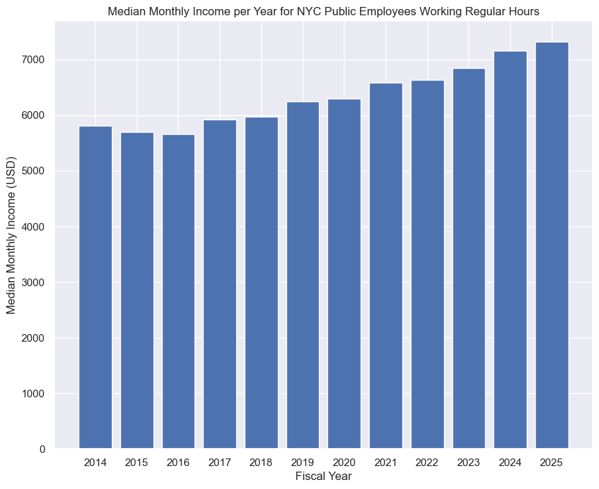

```python
plt.figure(figsize=(10, 8))
plt.bar(cwpd["Fiscal Year"].unique()[::-1], cwpd[["Fiscal Year", "Annual Salary Estimate"]].groupby("Fiscal Year").median()['Annual Salary Estimate'] / 12)
plt.xticks(cwpd["Fiscal Year"].unique()[::-1])
plt.title("Median Monthly Income per Year for NYC Public Employees Working Regular Hours")
plt.ylabel("Median Monthly Income (USD)")
plt.xlabel("Fiscal Year")
plt.show()
```

As well as the annual salary estimate for the same period:

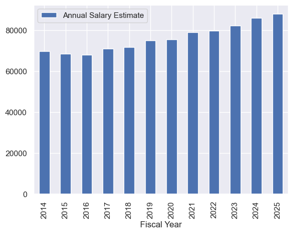

```python
cwpd[["Fiscal Year", "Annual Salary Estimate"]].groupby("Fiscal Year").median().plot(kind='bar');
```

After getting an idea about the basic distribution and summaries of some of the key variables, some more in-depth plots and new dataframes were made, to prepare for making the final visualizations. First, a plot for the evolution of the average income per year, for each of the boroughs - as well as the NYC total - was made, to get an idea of potential differences between income in the different boroughs.

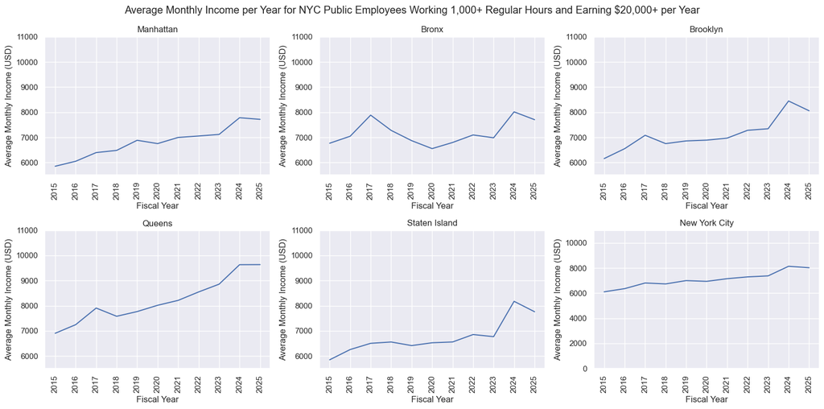

```python
same_y_lims = True

plt.figure(figsize=(16, 8))

for i, borough in enumerate(cwpd["Work Location Borough"].unique()):
    plt.subplot(2, 3, i+1)
    plt.plot(cwpd["Fiscal Year"].unique()[10::-1],
            cwpd[(cwpd["Work Location Borough"] == borough) &
                 (cwpd["Fiscal Year"] > 2014) &
                 (cwpd["Annual Salary Estimate"] > 20000)][["Fiscal Year", "Annual Salary Estimate"]].groupby("Fiscal Year").mean()['Annual Salary Estimate'] / 12)
    plt.title(borough)
    plt.xticks(cwpd["Fiscal Year"].unique()[10::-1], rotation='vertical')
    plt.ylabel("Average Monthly Income (USD)")
    plt.xlabel("Fiscal Year")
    if same_y_lims:
        plt.ylim(5500, 11000)

plt.subplot(2, 3, 6)
plt.plot(cwpd["Fiscal Year"].unique()[10::-1], cwpd[(cwpd["Fiscal Year"] > 2014) &
                                                   (cwpd["Annual Salary Estimate"] > 20000)][["Fiscal Year", "Annual Salary Estimate"]].groupby("Fiscal Year").mean()['Annual Salary Estimate'] / 12)
plt.xticks(cwpd["Fiscal Year"].unique()[10::-1], rotation='vertical')
plt.title("New York City")
plt.ylabel("Average Monthly Income (USD)")
plt.xlabel("Fiscal Year")
plt.ylim(0, 11000)

plt.suptitle("Average Monthly Income per Year for NYC Public Employees Working 1,000+ Regular Hours and Earning $20,000+ per Year")
plt.tight_layout()
plt.show()
```

A simple dataframe was made to keep track of the mean salaries for the boroughs across the years.

```python
borough_dists = []

for borough in cwpd["Work Location Borough"].unique():
    salaries = cwpd[(cwpd["Work Location Borough"] == borough) &
                 (cwpd["Fiscal Year"] > 2014) &
                 (cwpd["Annual Salary Estimate"] > 20000)][["Fiscal Year", "Annual Salary Estimate"]].groupby("Fiscal Year").mean()['Annual Salary Estimate'] / 12

    salaries_df = salaries.to_frame(name="Average Salary")
    salaries_df["Borough"] = borough
    salaries_df["Year"] = cwpd["Fiscal Year"].unique()[10::-1]
    borough_dists.append(salaries_df)

salaries = cwpd[(cwpd["Fiscal Year"] > 2014) &
                (cwpd["Annual Salary Estimate"] > 20000)][["Fiscal Year", "Annual Salary Estimate"]].groupby("Fiscal Year").mean()['Annual Salary Estimate'] / 12
salaries_df = salaries.to_frame(name='Average Salary')
salaries_df["Borough"] = "New York City"
salaries_df["Year"] = cwpd["Fiscal Year"].unique()[10::-1]
borough_dists.append(salaries_df)

borough_dist_df = pd.concat(borough_dists, ignore_index=True)
borough_dist_df
```

|  | Average Salary | Borough | Year |
| --- | --- | --- | --- |
| 0 | 5851.279242 | Manhattan | 2015 |
| 1 | 6049.603363 | Manhattan | 2016 |
| 2 | 6395.416073 | Manhattan | 2017 |
| 3 | 6482.399338 | Manhattan | 2018 |
| 4 | 6884.306102 | Manhattan | 2019 |
| ... | ... | ... | ... |
| 61 | 7150.772025 | New York City | 2021 |
| 62 | 7294.035807 | New York City | 2022 |
| 63 | 7373.810876 | New York City | 2023 |
| 64 | 8138.795831 | New York City | 2024 |
| 65 | 8024.618146 | New York City | 2025 |

66 rows × 3 columns

The previously cleaned rent data was loaded for comparison with salaries. Here the months were summed into years, as the payroll data was in fiscal years.

```python
rent = pd.read_csv("data/mean_rents.csv")
rent_raw = rent.copy()
rent_avg_df = rent.copy()

rent = rent.melt(
    id_vars=['apartmentType', 'Borough'],
    var_name='Year/Month',
    value_name='Rent'
)

for year in ["2014", "2015", "2016", "2017", "2018", "2019", "2020", "2021", "2022", "2023", "2024", "2025"]:
    nan_count = rent_avg_df.filter(like=year).isna().sum(axis=1)
    rent_avg_df[year] = rent_avg_df.filter(like=year).sum(axis=1) / (12 - nan_count)
rent_avg_df = rent_avg_df.filter(["apartmentType", "Borough", "2014", "2015", "2016", "2017", "2018", "2019", "2020", "2021", "2022", "2023", "2024", "2025"], axis=1)
rent_avg_df = rent_avg_df.melt(
    id_vars=['apartmentType', 'Borough'],
    var_name='Year',
    value_name='Rent'
)
```

A simple plot of the mean rent for each of the apartment types in each borough was made to get a sense of how the prices compared. It was also animated across years, to get a quick idea of the evolution over time.

```python
fig = px.bar(rent_avg_df,
             x='apartmentType', y='Rent', color='Borough', animation_frame='Year',
             title='Average Rent by Apartment Type and Borough',
             barmode='group',
             width=1400, height=600)

fig.show()
```

Here we discovered, that there was no rent data for studio apartments on Staten Island in 2014 at all, so we chose to use data in the years 2015-2025 for most of the analysis, as we had both rent and salary data in this timeframe.

As we wanted to analyze a handful of specific jobs, we looked at their value counts, and picked six popular and well-known jobs from the list.

```python
cwpd['Title Description'].str.upper().value_counts()
```

```
Title Description
TEACHER                                                      547559
ANNUAL ED PARA                                               266809
TEACHER SPECIAL EDUCATION                                    265207
POLICE OFFICER                                               255683
FIREFIGHTER                                                   92031
                                                              ...
DIRECTOR OF THE MAYOR?S OFFICE OF APPOINTMENTS                    1
DIRECTOR OF THE MAYOR?S OFFICE OF ADMINISTRATIVE SERVICES         1
SCHOOL MEDICAL INSPECTOR - REG SUB                                1
LAB SPECIALIST/ASSISTANT-REG SUB                                  1
CHIEF OPERATING OFFICER                                           1
Name: count, Length: 1912, dtype: int64
```

```python
focus_jobs = ['CITY MEDICAL SPECIALIST', 'FIREFIGHTER', 'POLICE OFFICER', 'SANITATION WORKER', 'STAFF NURSE', 'TEACHER']
```

A dataframe with the chosen jobs was created.

```python
focus_jobs_dists = []

for job in focus_jobs:
    salaries = np.round(cwpd[(cwpd['Title Description'] == job) &
                 (cwpd['Fiscal Year'] > 2014) &
                 (cwpd['Annual Salary Estimate'] > 20000)][['Fiscal Year', 'Annual Salary Estimate']].groupby('Fiscal Year').mean()['Annual Salary Estimate'] / 12, 2)

    salaries_df = salaries.to_frame(name='Average Salary')
    salaries_df['Job Title'] = job
    salaries_df['Year'] = cwpd['Fiscal Year'].unique()[10::-1]
    focus_jobs_dists.append(salaries_df)

focus_jobs_df = pd.concat(focus_jobs_dists, ignore_index=True)
focus_jobs_df['Job Title'] = focus_jobs_df['Job Title'].map({
    'CITY MEDICAL SPECIALIST': 'City Medical Specialist',
    'FIREFIGHTER': 'Firefighter',
    'POLICE OFFICER': 'Police Officer',
    'SANITATION WORKER': 'Sanitation Worker',
    'STAFF NURSE': 'Staff Nurse',
    'TEACHER': 'Teacher'
})
focus_jobs_df
```

|  | Average Salary | Job Title | Year |
| --- | --- | --- | --- |
| 0 | 12464.04 | City Medical Specialist | 2015 |
| 1 | 13961.79 | City Medical Specialist | 2016 |
| 2 | 14169.21 | City Medical Specialist | 2017 |
| 3 | 14246.21 | City Medical Specialist | 2018 |
| 4 | 14148.59 | City Medical Specialist | 2019 |
| ... | ... | ... | ... |
| 61 | 7817.27 | Teacher | 2021 |
| 62 | 7770.41 | Teacher | 2022 |
| 63 | 7988.69 | Teacher | 2023 |
| 64 | 8329.25 | Teacher | 2024 |
| 65 | 8631.95 | Teacher | 2025 |

66 rows × 3 columns

We wanted to analyze their salary changes from the first year as a baseline, so this was added as a column in the dataframe.

```python
base = focus_jobs_df[focus_jobs_df['Year'] == 2015].set_index('Job Title')['Average Salary']
focus_jobs_df['2015 Base Salary'] = focus_jobs_df['Job Title'].map(base)
focus_jobs_df['Percent Increase'] = np.round((focus_jobs_df['Average Salary'] - focus_jobs_df['2015 Base Salary']) / focus_jobs_df['2015 Base Salary'] * 100, 2)
```

Finally, we calculated some key numbers for our analysis and data story like this, which were used on the website:

```python
# Introduction numbers
print(f"Rent increase since 2015: {np.round((rent_avg_df[rent_avg_df['Year'] == '2025']['Rent'].mean() - rent_avg_df[rent_avg_df['Year'] == '2015']['Rent'].mean()) / rent_avg_df[rent_avg_df['Year'] == '2015']['Rent'].mean() * 100)}%")
print(f"Median public worker salary (2025): {np.round(cwpd[cwpd['Fiscal Year'] == 2025]['Annual Salary Estimate'].median(), -3)}$")
print(f"Median monthly rent (2025): {np.round(rent_avg_df[rent_avg_df['Year'] == '2025']['Rent'].median(), -2)}$")
print(f"Share of income spent on rent (before tax, 2025): {np.round(rent_avg_df[rent_avg_df['Year'] == '2025']['Rent'].median() / (cwpd[cwpd['Fiscal Year'] == 2025]['Annual Salary Estimate'].median() / 12) * 100)}%\n")

print(f"Median public worker salary (2015): {np.round(cwpd[cwpd['Fiscal Year'] == 2015]['Annual Salary Estimate'].median(), -3)}$")
print(f"Median monthly rent (2015): {np.round(rent_avg_df[rent_avg_df['Year'] == '2015']['Rent'].median(), -2)}$")
print(f"Share of income spent on rent (before tax, 2015): {np.round(rent_avg_df[rent_avg_df['Year'] == '2015']['Rent'].median() / (cwpd[cwpd['Fiscal Year'] == 2015]['Annual Salary Estimate'].median() / 12) * 100)}%\n")

print(f"Median public worker salary increase: {np.round((cwpd[cwpd['Fiscal Year'] == 2025]['Annual Salary Estimate'].median() / cwpd[cwpd['Fiscal Year'] == 2015]['Annual Salary Estimate'].median() - 1) * 100)}%")
print(f"Median monthly rent increase: {np.round((rent_avg_df[rent_avg_df['Year'] == '2025']['Rent'].median() / rent_avg_df[rent_avg_df['Year'] == '2015']['Rent'].median() - 1) * 100)}%")
print(f"Projected share spent on rent for 2035: {np.round((rent_avg_df[rent_avg_df['Year'] == '2025']['Rent'].median() * rent_avg_df[rent_avg_df['Year'] == '2025']['Rent'].median() / rent_avg_df[rent_avg_df['Year'] == '2015']['Rent'].median()) / (cwpd[cwpd['Fiscal Year'] == 2025]['Annual Salary Estimate'].median() * cwpd[cwpd['Fiscal Year'] == 2025]['Annual Salary Estimate'].median() / cwpd[cwpd['Fiscal Year'] == 2015]['Annual Salary Estimate'].median() / 12) * 100)}%\n")
print(f"Share of double income household spent on rent (before tax, 2025): {np.round(rent_avg_df[(rent_avg_df['Year'] == '2025') & (rent_avg_df['apartmentType'].isin(['Two bedrooms', 'Three plus bedrooms']))]['Rent'].median() / (cwpd[cwpd['Fiscal Year'] == 2025]['Annual Salary Estimate'].median() * 2 / 12) * 100)}%")
```

```
Rent increase since 2015: 50.0%
Median public worker salary (2025): 88000.0$
Median monthly rent (2025): 3300.0$
Share of income spent on rent (before tax, 2025): 45.0%

Median public worker salary (2015): 68000.0$
Median monthly rent (2015): 2300.0$
Share of income spent on rent (before tax, 2015): 40.0%

Median public worker salary increase: 28.0%
Median monthly rent increase: 42.0%
Projected share spent on rent for 2035: 49.0%

Share of double income household spent on rent (before tax, 2025): 27.0%
```

### Race data

In order to work with the race data, we had to make a mapping from that to the rent data. This was done using NTA codes and matching on keywords

```python
df_rent_area = pd.read_csv('data/mean_rents_by_area.csv')
df_rent_area['Borough'] = df_rent_area['Borough'].str.upper()

rent_long = df_rent_area.melt(
    id_vars=["apartmentType", "Borough", "areaName"],
    var_name="month",
    value_name="rent"
)

rent_long["year"] = rent_long["month"].str.slice(0, 4)

rent_yearly = (
    rent_long
    .groupby(["Borough", "areaName", "year"], as_index=False)
    .agg(rent_mean=("rent", "mean"))
)

nta_df = pd.read_excel("data/nyc2020census_tract_nta_cdta_relationships.xlsx")
nta_df = nta_df[["GEOID", "BoroName", "CT2020", "NTACode", "NTAName", "CDTACode", "CDTAName"]].dropna()
# collapse duplicates using MOST COMMON NTA code
nta_clean = (
    nta_df.groupby("NTAName")[["GEOID", "BoroName", "CT2020", "NTACode", "CDTACode", "CDTAName"]]
    .agg(lambda x: x.value_counts().idxmax())
    .reset_index()
)

nta_clean = nta_clean.rename(columns={
    "CountyFIPS": "county",
    "CT2020": "tract",
    "NTACode": "NTA",
    "NTAName": "NTA_name"
})

nta_by_boro = {
    "Bronx": nta_clean[nta_clean["NTA"].str.startswith("BX")],
    "Brooklyn": nta_clean[nta_clean["NTA"].str.startswith("BK")],
    "Manhattan": nta_clean[nta_clean["NTA"].str.startswith("MN")],
    "Queens": nta_clean[nta_clean["NTA"].str.startswith("QN")],
    "Staten Island": nta_clean[nta_clean["NTA"].str.startswith("SI")],
}

representative = {
    # Manhattan aggregates
    "All Downtown": "Battery Park City-Lower Manhattan",
    "All Midtown": "Midtown-Midtown South",
    "All Upper East Side": "Upper East Side-Carnegie Hill",
    "All Upper West Side": "Upper West Side-Lincoln Square",
    "All Upper Manhattan": "Harlem (North)",
    "Manhattan": "Midtown-Midtown South",
    "NYC": "Midtown-Midtown South",

    # Brooklyn aggregates
    "North Brooklyn": "North Side-South Side",
    "South Brooklyn": "Sunset Park (Central)",
    "East Brooklyn": "East New York",
    "Northwest Brooklyn": "Downtown Brooklyn-DUMBO-Boerum Hill",
    "Brooklyn": "Downtown Brooklyn-DUMBO-Boerum Hill",

    # Queens aggregates
    "Central Queens": "Forest Hills",
    "Northwest Queens": "Astoria (Central)",
    "Northeast Queens": "Bayside-Bayside Hills",
    "Rockaway All": "Far Rockaway-Bayswater",
    "The Rockaways": "Rockaway Beach-Arverne-Edgemere",
    "Queens": "Flushing",

    # Bronx aggregates
    "Bronx": "Mott Haven-Port Morris",

    # Staten Island aggregates
    "Staten Island": "St. George-New Brighton",
}

park_to_residential = {
    "Prospect Park": "Park Slope-Gowanus",
    "Prospect Park South": "Park Slope-Gowanus",
    "Central Park South": "Upper West Side-Lincoln Square",
    "Forest Park": "Woodhaven",
    "Van Cortlandt Park": "North Riverdale-Fieldston-Riverdale",
}


def keyword_match(area, borough):
    words = re.findall(r"[A-Za-z]+", area.lower())
    candidates = nta_by_boro[borough]

    scores = []
    for _, row in candidates.iterrows():
        nta = row["NTA_name"].lower()
        score = sum(w in nta for w in words)
        scores.append((row["NTA_name"], score))

    best = max(scores, key=lambda x: x[1])
    return best[0]

rows = []

for _, row in rent_yearly.iterrows():
    area = row["areaName"]
    boro = row["Borough"]

    # override: aggregates
    if area in representative:
        nta_name = representative[area]

    # override: parks
    elif area in park_to_residential:
        nta_name = park_to_residential[area]

    # normal keyword match
    else:
        nta_name = keyword_match(area, boro)

    rows.append([area, boro, nta_name])

area_to_nta = pd.DataFrame(rows, columns=["areaName", "Borough", "NTA_name"])

# merge NTA codes from nta_clean
area_to_nta = area_to_nta.merge(nta_clean, on="NTA_name", how="left")

# drop duplicates
area_to_nta = area_to_nta.drop_duplicates()

# sort by Borough then areaName
area_to_nta = area_to_nta.sort_values(["Borough", "areaName"])

# area_to_nta.to_csv("area_to_nta.csv", index=False)
```

The race data was then loaded and cleaned so we could see wich columns corresponded to what race, and which year. After that the data is merged. As the US cencus is made every 10 years we had data from 2010 and 2020

```python
df_rent_area = pd.read_csv('data/mean_rents_by_area.csv')
df_rent_area['Borough'] = df_rent_area['Borough'].str.upper()

rent_long = df_rent_area.melt(
    id_vars=["apartmentType", "Borough", "areaName"],
    var_name="month",
    value_name="rent"
)

rent_long["year"] = rent_long["month"].str.slice(0, 4)

rent_yearly = (
    rent_long
    .groupby(["Borough", "areaName", "year"], as_index=False)
    .agg(rent_mean=("rent", "mean"))
)
```

```python
def load_acs(table, year, api_key):
    params = {
        "get": "NAME," + ",".join([f"{table}_{i:03d}E" for i in range(1, 10)]),
        "for": "tract:*",
        "in": "state:36 county:*",
        "key": api_key
    }
    url = f"https://api.census.gov/data/{year}/acs/acs5"
    r = requests.get(url, params=params)


    if r.status_code != 200:
        print(f"Error response received")
        return None

    try:
        data = r.json()
        return pd.DataFrame(data[1:], columns=data[0])
    except Exception as e:
        print(f"JSON parsing failed: {e}")
        return None

key = "Get an API key from https://api.census.gov/data/key_signup.html and add it here"
race2010 = load_acs("B02001", 2010, key)
race2020 = load_acs("B02001", 2020, key)
```

```python
def clean_race(df, year):
    df = df.rename(columns={
        "B02001_001E": f"total_{year}",
        "B02001_002E": f"white_{year}",
        "B02001_003E": f"black_{year}",
        "B02001_004E": f"native_{year}",
        "B02001_005E": f"asian_{year}",
        "B02001_006E": f"pi_{year}",
        "B02001_007E": f"other_{year}"
    })
    df = df.drop(columns=["B02001_008E", "B02001_009E"], errors="ignore")

    # Convert race columns to numeric (int)
    race_cols = [f"total_{year}", f"white_{year}", f"black_{year}",
                 f"native_{year}", f"asian_{year}", f"pi_{year}", f"other_{year}"]
    for col in race_cols:
        df[col] = pd.to_numeric(df[col], errors="coerce").fillna(0).astype(int)

    return df

race2010 = clean_race(race2010,2010)
race2020 = clean_race(race2020,2020)
```

Then the NTA data was loaded to fin out wich areas each row in the race data belonged to

```python
nta10 = pd.read_excel('data/nyc2010census_tabulation_equiv.xlsx', skiprows=3)
nta10 = nta10.dropna(subset=["2010 Census Tract"]).rename(columns={
    "2010 Census Bureau FIPS County Code": "county",
    "2010 Census Tract": "tract",
    "Neighborhood Tabulation Area (NTA)": "NTA",
    "Unnamed: 6": "NTA_name"
})
nta10["tract"] = nta10["tract"].astype(float).astype(int).astype(str).str.zfill(6)
nta10["county"] = nta10["county"].astype(float).astype(int).astype(str).str.zfill(3)
nta10["state"] = "36"

nta20 = pd.read_excel('data/nyc2020census_tract_nta_cdta_relationships.xlsx')
nta20 = nta20.rename(columns={
    "CountyFIPS": "county",
    "CT2020": "tract",
    "NTACode": "NTA",
    "NTAName": "NTA_name"
})
nta20["tract"] = nta20["tract"].astype(str).str.zfill(6)
nta20["county"] = nta20["county"].astype(str).str.zfill(3)
nta20["state"] = "36"
```

```python
# --- Normalize merge keys for ACS and NTA ---
for df in [race2010, race2020, nta10, nta20]:
    df["state"] = df["state"].astype(str).str.zfill(2)
    df["county"] = df["county"].astype(str).str.zfill(3)
    df["tract"] = (
        df["tract"]
        .astype(str)
        .str.replace(".0", "", regex=False)
        .str.replace(".", "", regex=False)
        .str.zfill(6)
    )
```

```python
# NYC county FIPS codes
nyc_counties = ["005", "047", "061", "081", "085"]  # Bronx, Kings, New York, Queens, Richmond

race2010 = race2010[race2010["county"].isin(nyc_counties)]
race2020 = race2020[race2020["county"].isin(nyc_counties)]

# Drop rows with zero population
race2010 = race2010[race2010["total_2010"] > 0]
race2020 = race2020[race2020["total_2020"] > 0]
```

```python
race_tract = race2010.merge(
    race2020,
    on=["state", "county", "tract"],
    how="outer"
).dropna()
```

The NTA and race data is then merged, and then merged with the rent data

```python
area_to_nta = pd.read_csv('area_to_nta.csv')
area_to_nta['Borough'] = area_to_nta["Borough"].str.capitalize()
area_to_nta["tract"] = (area_to_nta["tract"].astype(str)
        .str.replace(".0", "", regex=False)
        .str.replace(".", "", regex=False)
        .str.zfill(6))

race_tract = race_tract.merge(nta20, on=["state", "county", "tract"], how="left")

area_to_nta = pd.read_csv('area_to_nta.csv')
area_to_nta["tract"] = (area_to_nta["tract"].astype(str)
        .str.replace(".0", "", regex=False)
        .str.replace(".", "", regex=False)
        .str.zfill(6))
rent_with_nta = rent_yearly[rent_yearly["year"].isin(["2010", "2020"])].merge(
    area_to_nta,
    on=["areaName", "Borough"],
    how="left"
)
```

```python
groups = ["white", "black", "asian", "native", "pi", "other"]
agg_race = race_tract.groupby("NTA_name", as_index=False).agg(
    {f"{g}_2010": "sum" for g in groups} |
    {f"{g}_2020": "sum" for g in groups} |
    {"total_2010": "sum", "total_2020": "sum"} |
    {"NTA": "first", "BoroName": "first", "CDTACode": "first", "CDTAName": "first", "GEOID": "first", "tract": "first"}
)

# Group rent data by NTA_name and year, take mean
rent_by_nta = rent_with_nta.groupby(["NTA_name", "year"], as_index=False).agg({
    "rent_mean": "mean"
}).rename(columns={"rent_mean": "rent_mean_nta"})

# Reshape agg_race to long format (one row per NTA per year)
agg_race_long = []

for _, row in agg_race.iterrows():
    for year in [2010, 2020]:
        agg_race_long.append({
            "NTA_name": row["NTA_name"],
            "year": str(year),
            **{g: row[f"{g}_{year}"] for g in groups},
            "total": row[f"total_{year}"],
            "NTA": row["NTA"],
            "BoroName": row["BoroName"],
            "CDTACode": row["CDTACode"],
            "CDTAName": row["CDTAName"],
            "GEOID": row["GEOID"]
        })

agg_race_long = pd.DataFrame(agg_race_long)


# Calculate race shares directly in agg_race_long
for g in groups:
    agg_race_long[f"{g}_share"] = agg_race_long[g] / agg_race_long["total"]

# Merge with rent
final = agg_race_long.merge(rent_by_nta, on=["NTA_name", "year"], how="left")

# Reshape agg_race to long format (one row per NTA per year)
agg_race_long = []

for _, row in agg_race.iterrows():
    for year in [2010, 2020]:
        agg_race_long.append({
            "NTA_name": row["NTA_name"],
            "year": str(year),
            **{g: row[f"{g}_{year}"] for g in groups},
            "total": row[f"total_{year}"],
            "NTA": row["NTA"],
            "BoroName": row["BoroName"],
            "CDTACode": row["CDTACode"],
            "CDTAName": row["CDTAName"],
            "GEOID": row["GEOID"]
        })

agg_race_long = pd.DataFrame(agg_race_long)


# Calculate race shares directly in agg_race_long
for g in groups:
    agg_race_long[f"{g}_share"] = agg_race_long[g] / agg_race_long["total"]

# Merge with rent
final = agg_race_long.merge(rent_by_nta, on=["NTA_name", "year"], how="left")
```

```python
# Calculate shares in long format
for g in groups:
    final[f"{g}_share"] = final[g] / final["total"]

# Pivot to get 2010 and 2020 side by side (just for these columns)
final_wide = final.pivot_table(
    index="NTA_name",
    columns="year",
    values=[f"{g}_share" for g in groups] + ["rent_mean_nta"],
    aggfunc="first"
).reset_index()

# Flatten and calculate changes
final_wide.columns = ["_".join(col).strip("_") for col in final_wide.columns]

for g in groups:
    if f"{g}_share_2010" in final_wide.columns and f"{g}_share_2020" in final_wide.columns:
        final_wide[f"{g}_share_change"] = final_wide[f"{g}_share_2020"] - final_wide[f"{g}_share_2010"]

final_wide["rent_change"] = final_wide["rent_mean_nta_2020"] - final_wide["rent_mean_nta_2010"]

# final_wide.head()
```

```python
final_wide["rent_change_pct"] = (final_wide["rent_mean_nta_2020"] - final_wide["rent_mean_nta_2010"]) / final_wide["rent_mean_nta_2010"]
final_wide["white_change"] = final_wide["white_share_2020"] - final_wide["white_share_2010"]
final_wide["black_change"] = final_wide["black_share_2020"] - final_wide["black_share_2010"]
final_wide["asian_change"] = final_wide["asian_share_2020"] - final_wide["asian_share_2010"]
final_wide["pi_change"] = final_wide["pi_share_2020"] - final_wide["pi_share_2010"]
final_wide["native_change"] = final_wide["native_share_2020"] - final_wide["native_share_2010"]
final_wide["other_change"] = final_wide["other_share_2020"] - final_wide["other_share_2010"]
```

We made some quick linear regression to see if there was a correlation between the distribution of races in an area with the change in rent, but no correlation was found

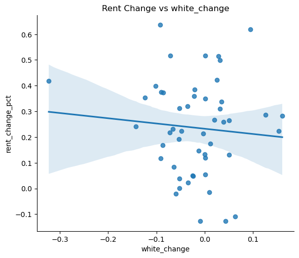

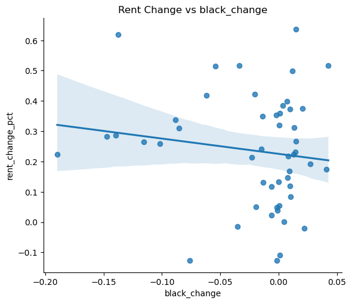

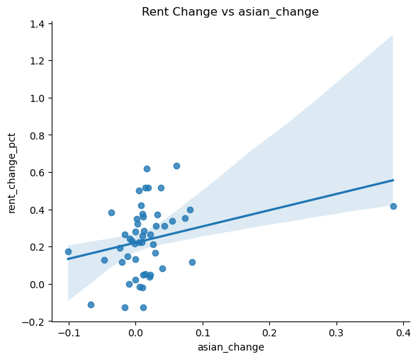

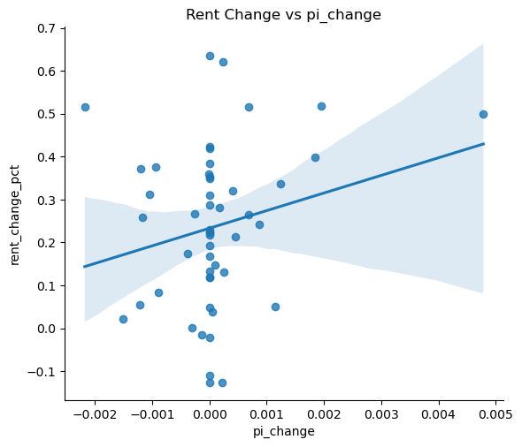

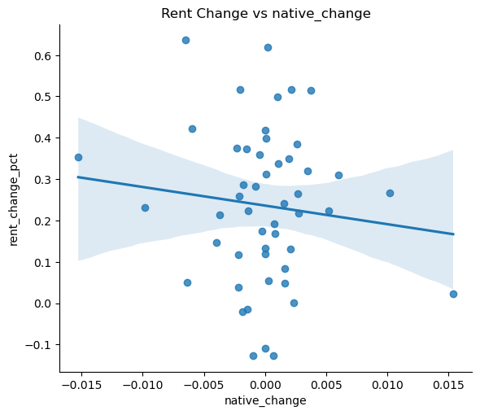

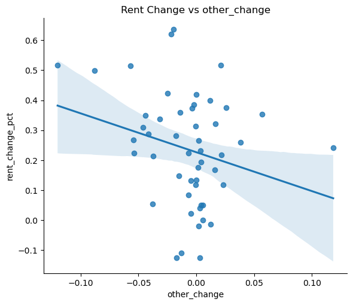

```python
for race in ["white_change","black_change","asian_change","pi_change","native_change","other_change"]:
    sns.lmplot(data=final_wide, x=race, y="rent_change_pct", height=5, aspect=1.2)
    plt.title(f"Rent Change vs {race}")
    plt.show()
```

## Visualizations

> - Explain the visualizations you've chosen? Why are they right for the story you want to tell?

Lets first look at figure 1-2, both of the visualizations were designed to show how public-sector salaries and housing affordability in New York City changed between 2015 and 2025. The first figure uses two line charts to compare salary trends across major public-sector jobs.

- The top chart in figure 1 focuses on percentage salary growth since 2015, allowing viewers to compare how quickly different professions’ wages increased over time. The bottom chart on figure 1 shows actual average salaries in dollars, helping viewers understand real earning levels alongside growth rates. Using separate panels provides both relative and absolute comparisons, making the analysis more balanced and meaningful.
- Figure 2 compares public-sector salaries with rising apartment rents across NYC boroughs. A combination of bar charts and line graphs was used to clearly distinguish salary levels from housing costs. Bars represent yearly average salaries, while lines illustrate rent trends for different apartment sizes, including studios, one-bedroom, two-bedroom, and three-bedroom units. This visualization highlights how rent increases have continued to place pressure on affordability despite salary growth. Interactive borough filters further improve the analysis by allowing users to explore geographic differences in housing costs and income trends. Overall, the visualizations tell a clear story: although public-sector salaries in NYC have generally increased over the past decade, rising housing costs continue to challenge affordability for many workers.

Lastly lets look at figure 3-4. The visualizations together tell a clear story about housing inequality and affordability in NYC from two angles:

- The choropleth maps (Figure 3) show how much money public workers have left after rent across boroughs, apartment types, and time. Green areas mean more affordability, while red areas show rent burden or negative disposable income. Larger apartments and certain boroughs are consistently less affordable, and trends change over time.
- The stacked bar charts (Figure 4) show that expensive neighborhoods tend to have less diverse, more White-dominant populations, while cheaper neighborhoods are more racially diverse. This highlights a link between neighborhood cost and demographic patterns.

### Figure 1

Figure 1 was made with the earlier created dataframe for the focus jobs. The code is as follows:

```python
focus_jobs = ['City Medical Specialist', 'Firefighter', 'Police Officer', 'Sanitation Worker', 'Staff Nurse', 'Teacher']

fig = make_subplots(rows=2, cols=1, vertical_spacing=0.12,
                    subplot_titles=('Mean Percent Increase Since 2015 For Popular Jobs (NYC)',
                                    'Mean Salaries For Popular Jobs (NYC)',))

for i, job in enumerate(focus_jobs):
    fig.append_trace(go.Scatter(x=focus_jobs_df[focus_jobs_df["Job Title"] == job]['Year'],
                                y=focus_jobs_df[focus_jobs_df["Job Title"] == job]['Percent Increase'],
                mode='lines+markers',
                name=job,
                legendgroup="pct increase",
                legendgrouptitle_text="Job Title",
                marker=dict(color=earth_tone_colors[i], size=5),
                line=dict(color=earth_tone_colors[i], width=2),
                ), row=1, col=1)

    fig.append_trace(go.Scatter(x=focus_jobs_df[focus_jobs_df["Job Title"] == job]['Year'],
                                y=focus_jobs_df[focus_jobs_df["Job Title"] == job]['Average Salary'],
                mode='lines+markers',
                name=job,
                legendgroup="salary",
                legendgrouptitle_text="Job Title",
                legend='legend2',
                marker=dict(color=earth_tone_colors[i], size=5),
                line=dict(color=earth_tone_colors[i], width=2),
                ), row=2, col=1)

fig.update_xaxes(tickmode = 'array', tickvals = np.linspace(2015, 2026, 12), gridcolor='#f5f4f2', title_text="Year")
fig.update_yaxes(gridcolor='#c4b8a8', zerolinecolor='#c4b8a8')
fig.update_yaxes(title_text='Increase (%)', row=1, col=1)
fig.update_yaxes(title_text='Salary (USD)', row=2, col=1)
fig.update_layout(width=550, height=710, margin=dict(t=40, b=50, l=50, r=30),
                  hovermode="x unified",
                  paper_bgcolor='#ede6dc',
                  plot_bgcolor='#f5f4f2',
                  font_color='#2e2a24',
                  legend=dict(groupclick="toggleitem",
                              font=dict(size=10),
                              yanchor="top",
                              y=0.99,
                              xanchor="left",
                              x=0.01,
                              bgcolor='rgba(237, 230, 220, 0.5)'),
                  legend2=dict(groupclick="toggleitem",
                               font=dict(size=10),
                            #    y=0.19
                               yanchor="top",
                               y=0.43,
                               xanchor="left",
                               x=0.01,
                               bgcolor='rgba(237, 230, 220, 0.5)'),
                  )

# fig.write_html("visualizations/pop_jobs_salaries_and_increase.html")
fig.show()
```

### Figure 2

Figure 2 consists of 6 plots, which was made with the borough distribution and average rent dataframes created earlier. The code is as follows:

```python
for borough in ['Manhattan', 'Queens', 'Brooklyn', 'Bronx', 'Staten Island', 'New York City']:
       fig = px.line(rent_avg_df[(rent_avg_df['Borough'] == borough) & (rent_avg_df['Year'] != '2014')],
                     x='Year', y='Rent', color='apartmentType',
                     title=f'Mean Salary and Rent for Different Apartment Types by Year ({borough})',
                     markers=True,
                     color_discrete_sequence=earth_tone_colors[1:],
                     width=1190, height=480)

       fig.update_xaxes(tickmode = 'array', tickvals = np.linspace(2015, 2026, 12), title_text='Year')
       fig.update_yaxes(gridcolor='#c4b8a8', zerolinecolor='#c4b8a8', title_text='Rent / Salary (USD)')
       fig.add_traces([
              go.Bar(x=borough_dist_df[borough_dist_df["Borough"] == borough]['Year'],
                     y=borough_dist_df[borough_dist_df["Borough"] == borough]['Average Salary'],
                     legendgroup="salary",
                     legendgrouptitle_text="Mean Salary",
                     name = borough,
                     marker=dict(color='#2e4460')
                     )
              ])
       if (borough != 'New York City'):
              fig.add_traces([
                     go.Bar(x=borough_dist_df[borough_dist_df["Borough"] == 'New York City']['Year'],
                            y=borough_dist_df[borough_dist_df["Borough"] == 'New York City']['Average Salary'],
                            legendgroup="salary",
                            name = 'NYC Mean',
                            marker=dict(color="#b8724e"),
                            visible='legendonly'
                     )
              ])

       fig.update_layout(legend_title_text='Apartment Type',
                         legend=dict(groupclick="toggleitem"),
                         paper_bgcolor='#ede6dc',
                         plot_bgcolor='#f5f4f2',
                         font_color='#2e2a24'
                         )

       # fig.write_html(f"visualizations/rent_vs_salary_by_year_{borough.lower().replace(' ', '_')}.html")

fig.show()
```

### Figure 3

In the cells below is the code used for making the map of how much money public workers in each borough have left after tax and paying rent. A function was made to compute how much tax a single person would approximately pay for each year. As the map is too large, it can not be shown in this notebook.

```python
df_rent = pd.read_csv('data/mean_rents.csv')
df_income = pd.read_csv('data/income_data.csv')
df_income['Work Location Borough'] = df_income['Work Location Borough'].replace('Richmond', 'Staten Island')

df_income['Total Income'] = df_income['Regular Gross Paid'] + df_income['Total OT Paid'] + df_income['Total Other Pay']

df_income_borough_year = df_income.groupby(['Fiscal Year', 'Work Location Borough'])['Total Income'].mean().reset_index()
df_income_borough_year.columns = ['Fiscal Year', 'Borough', 'Average Income']

df_income_borough_year_pivot = df_income.pivot_table(
    index='Work Location Borough',
    columns='Fiscal Year',
    values='Total Income',
    aggfunc='mean'
)
df_income_borough_year_pivot.reset_index(inplace=True)
df_income_borough_year_pivot.head()

# Convert annual income to monthly
df_income_monthly = df_income.pivot_table(
    index='Work Location Borough',
    columns='Fiscal Year',
    values='Total Income',
    aggfunc='mean'
) / 12


# Load from URL
url = "https://raw.githubusercontent.com/dwillis/nyc-maps/master/boroughs.geojson"
counties = requests.get(url).json()

# Extract one-bedroom rent data for January 2016
df_onebd_rent = df_rent[df_rent['apartmentType'] == 'One bedroom'].copy()
df_data = df_onebd_rent[['Borough', '2016-01']].copy()
df_data.columns = ['Borough', 'Rent_Jan_2016']
df_data = df_data.dropna()

# Get 2016 income and convert to monthly
df_income_2016 = df_income_borough_year_pivot[['Work Location Borough', 2016]].copy()
df_income_2016.columns = ['Borough', 'Annual_Income']
df_income_2016['Monthly_Income'] = df_income_2016['Annual_Income'] / 12

df_data = df_data.merge(df_income_2016[['Borough', 'Monthly_Income']], on='Borough')
```

```python
def calculate_after_tax_income(annual_income, borough, year):
    """
    Calculate after-tax income for a given year in NYC
    Includes: Federal, NY State, NYC, and FICA taxes with year-specific brackets
    """

    # FICA taxes - flat rate (unchanged 2014-2025)
    fica_rate = 0.0765
    fica_tax = annual_income * fica_rate

    # Federal income tax brackets (single filer) - varies by year
    federal_brackets = {
        2014: [(9075, 0.10), (36900, 0.15), (89075, 0.25), (189300, 0.28), (411500, 0.33), (413200, 0.35), (float('inf'), 0.396)],
        2015: [(9225, 0.10), (37450, 0.15), (90750, 0.25), (189300, 0.28), (411500, 0.33), (413200, 0.35), (float('inf'), 0.396)],
        2016: [(9300, 0.10), (37650, 0.15), (91150, 0.25), (190150, 0.28), (413350, 0.33), (415050, 0.35), (float('inf'), 0.396)],
        2017: [(9325, 0.10), (37950, 0.15), (91900, 0.25), (191650, 0.28), (416700, 0.33), (418400, 0.35), (float('inf'), 0.396)],
        2018: [(9525, 0.10), (38700, 0.12), (82500, 0.22), (157500, 0.24), (200000, 0.32), (500000, 0.35), (float('inf'), 0.37)],
        2019: [(9700, 0.10), (39475, 0.12), (84200, 0.22), (160725, 0.24), (204100, 0.32), (511000, 0.35), (float('inf'), 0.37)],
        2020: [(9875, 0.10), (40125, 0.12), (85525, 0.22), (163300, 0.24), (207350, 0.32), (518400, 0.35), (float('inf'), 0.37)],
        2021: [(9950, 0.10), (40525, 0.12), (86375, 0.22), (164925, 0.24), (209425, 0.32), (523600, 0.35), (float('inf'), 0.37)],
        2022: [(10275, 0.10), (41775, 0.12), (89075, 0.22), (170050, 0.24), (215950, 0.32), (539900, 0.35), (float('inf'), 0.37)],
        2023: [(11000, 0.10), (44725, 0.12), (95375, 0.22), (182100, 0.24), (231250, 0.32), (578125, 0.35), (float('inf'), 0.37)],
        2024: [(11600, 0.10), (47150, 0.12), (100525, 0.22), (191950, 0.24), (243725, 0.32), (609350, 0.35), (float('inf'), 0.37)],
        2025: [(11950, 0.10), (48575, 0.12), (103500, 0.22), (198050, 0.24), (250525, 0.32), (626350, 0.35), (float('inf'), 0.37)],
    }

    # NY State income tax brackets (single filer) - varies by year
    ny_state_brackets = {
        2014: [(4200, 0.04), (8200, 0.045), (13450, 0.0475), (21300, 0.055), (80650, 0.065), (215400, 0.0685), (float('inf'), 0.0965)],
        2015: [(4300, 0.04), (8400, 0.045), (13750, 0.0475), (21800, 0.055), (80650, 0.065), (215400, 0.0685), (float('inf'), 0.0965)],
        2016: [(4400, 0.04), (8650, 0.045), (14100, 0.0475), (22350, 0.055), (80650, 0.065), (215400, 0.0685), (float('inf'), 0.0965)],
        2017: [(4500, 0.04), (8850, 0.045), (14450, 0.0475), (22800, 0.055), (80650, 0.065), (215400, 0.0685), (float('inf'), 0.0965)],
        2018: [(4600, 0.04), (9100, 0.045), (14850, 0.0475), (23400, 0.055), (80650, 0.065), (215400, 0.0685), (float('inf'), 0.0965)],
        2019: [(4850, 0.04), (9500, 0.045), (15550, 0.0475), (24650, 0.055), (81200, 0.065), (215050, 0.0685), (float('inf'), 0.0965)],
        2020: [(4950, 0.04), (9700, 0.045), (15900, 0.0475), (25150, 0.055), (82900, 0.065), (215400, 0.0685), (float('inf'), 0.0965)],
        2021: [(5050, 0.04), (9900, 0.045), (16200, 0.0475), (25650, 0.055), (84500, 0.065), (219600, 0.0685), (float('inf'), 0.0965)],
        2022: [(5250, 0.04), (10300, 0.045), (16850, 0.0475), (26650, 0.055), (87650, 0.065), (228150, 0.0685), (float('inf'), 0.0965)],
        2023: [(5850, 0.04), (11450, 0.045), (18700, 0.0475), (29500, 0.055), (96750, 0.065), (252500, 0.0685), (float('inf'), 0.0965)],
        2024: [(6100, 0.04), (12000, 0.045), (19550, 0.0475), (30850, 0.055), (101050, 0.065), (263550, 0.0685), (float('inf'), 0.0965)],
        2025: [(6300, 0.04), (12400, 0.045), (20200, 0.0475), (31850, 0.055), (104000, 0.065), (272000, 0.0685), (float('inf'), 0.0965)],
    }

    # NYC income tax brackets (single filer) - varies by year
    nyc_brackets = {
        2014: [(11500, 0.03876), (23700, 0.04391), (50000, 0.04876), (float('inf'), 0.05876)],
        2015: [(11800, 0.03876), (24200, 0.04391), (51000, 0.04876), (float('inf'), 0.05876)],
        2016: [(12000, 0.03876), (24700, 0.04391), (52000, 0.04876), (float('inf'), 0.05876)],
        2017: [(12500, 0.03876), (25600, 0.04391), (53200, 0.04876), (float('inf'), 0.05876)],
        2018: [(12800, 0.03876), (26200, 0.04391), (54400, 0.04876), (float('inf'), 0.05876)],
        2019: [(13400, 0.03876), (27300, 0.04391), (56500, 0.04876), (float('inf'), 0.05876)],
        2020: [(13700, 0.03876), (27900, 0.04391), (57800, 0.04876), (float('inf'), 0.05876)],
        2021: [(14000, 0.03876), (28500, 0.04391), (59000, 0.04876), (float('inf'), 0.05876)],
        2022: [(14500, 0.03876), (29600, 0.04391), (61200, 0.04876), (float('inf'), 0.05876)],
        2023: [(16000, 0.03876), (32650, 0.04391), (67500, 0.04876), (float('inf'), 0.05876)],
        2024: [(16700, 0.03876), (34000, 0.04391), (70300, 0.04876), (float('inf'), 0.05876)],
        2025: [(17200, 0.03876), (35200, 0.04391), (72500, 0.04876), (float('inf'), 0.05876)],
    }

    # Helper function to calculate tax from brackets
    def calculate_tax_from_brackets(income, brackets_dict, year):
        tax = 0
        brackets = brackets_dict.get(year, brackets_dict[2016])
        previous_limit = 0
        for limit, rate in brackets:
            if income > previous_limit:
                taxable_in_bracket = min(income, limit) - previous_limit
                tax += taxable_in_bracket * rate
                previous_limit = limit
            else:
                break
        return tax

    # Calculate federal tax
    federal_tax = calculate_tax_from_brackets(annual_income, federal_brackets, year)

    # Calculate NY State tax
    ny_state_tax = calculate_tax_from_brackets(annual_income, ny_state_brackets, year)

    # Calculate NYC tax
    nyc_tax = calculate_tax_from_brackets(annual_income, nyc_brackets, year)

    total_tax = fica_tax + federal_tax + ny_state_tax + nyc_tax
    after_tax = annual_income - total_tax

    return after_tax
```

```python
apartment_types = ['Studio', 'One bedroom', 'Two bedrooms', 'Three plus bedrooms']
years = sorted(df_income_borough_year_pivot.columns[1:])

# Prepare data for all combinations to get global min/max
all_differences = []
for year in years:
    for apt_type in apartment_types:
        rent_cols = [col for col in df_rent.columns if col.startswith(f'{year}-')]
        df_apt_rent = df_rent[df_rent['apartmentType'] == apt_type].copy()
        df_apt = df_apt_rent[['Borough']].copy()
        df_apt['Rent'] = df_apt_rent[rent_cols].mean(axis=1)
        df_apt = df_apt.dropna()

        if len(df_apt) > 0:
            df_income_year = df_income_borough_year_pivot[['Work Location Borough', year]].copy()
            df_income_year.columns = ['Borough', 'Annual_Income']
            df_income_year['Monthly_Income'] = df_income_year['Annual_Income'] / 12

            df_apt = df_apt.merge(df_income_year[['Borough', 'Monthly_Income']], on='Borough')
            df_apt['Annual_Income'] = df_apt['Monthly_Income'] * 12
            df_apt['After_Tax_Annual'] = df_apt.apply(
                lambda r: calculate_after_tax_income(r['Annual_Income'], r['Borough'], year),
                axis=1
            )
            df_apt['After_Tax_Monthly'] = df_apt['After_Tax_Annual'] / 12
            df_apt['Difference'] = df_apt['After_Tax_Monthly'] - df_apt['Rent']
            all_differences.extend(df_apt['Difference'].dropna().values)

global_min = min(all_differences)
global_max = max(all_differences)
```

```python
normalized_1000 = (1000 - global_min) / (global_max - global_min)
normalized_1000 = max(0, min(1, normalized_1000))

custom_colorscale = [
    [0, 'red'],                    # Min value → red
    [normalized_1000, 'yellow'],   # $1000 → yellow (at correct normalized position)
    [1, 'green']                   # Max value → green
]

fig = make_subplots(
    rows=2, cols=2,
    subplot_titles=apartment_types,
    specs=[[{'type': 'mapbox'}, {'type': 'mapbox'}],
           [{'type': 'mapbox'}, {'type': 'mapbox'}]],
    horizontal_spacing=0.02,
    vertical_spacing=0.05
)

# Create frames for animation
frames = []
for year in years:
    frame_traces = []
    for apt_type in apartment_types:
        rent_cols = [col for col in df_rent.columns if col.startswith(f'{year}-')]
        df_apt_rent = df_rent[df_rent['apartmentType'] == apt_type].copy()
        df_apt = df_apt_rent[['Borough']].copy()
        df_apt['Rent'] = df_apt_rent[rent_cols].mean(axis=1)
        df_apt = df_apt.dropna()

        if len(df_apt) > 0:
            df_income_year = df_income_borough_year_pivot[['Work Location Borough', year]].copy()
            df_income_year.columns = ['Borough', 'Annual_Income']
            df_income_year['Monthly_Income'] = df_income_year['Annual_Income'] / 12

            df_apt = df_apt.merge(df_income_year[['Borough', 'Monthly_Income']], on='Borough')
            df_apt['Annual_Income'] = df_apt['Monthly_Income'] * 12
            df_apt['After_Tax_Annual'] = df_apt.apply(
                lambda r: calculate_after_tax_income(r['Annual_Income'], r['Borough'], year),
                axis=1
            )
            df_apt['After_Tax_Monthly'] = df_apt['After_Tax_Annual'] / 12
            df_apt['Difference'] = df_apt['After_Tax_Monthly'] - df_apt['Rent']
            df_apt['Borough'] = df_apt['Borough'].str.title()
        else:
            df_apt = pd.DataFrame({'Borough': [], 'Difference': []})


        trace = go.Choroplethmapbox(
            geojson=counties,
            locations=df_apt['Borough'],
            z=df_apt['Difference'],
            featureidkey='properties.BoroName',
            colorscale=custom_colorscale,
            zmin=global_min,
            zmax=global_max,
            showscale=(len(frame_traces) == 0),
            hovertemplate=(
                '<b>%{location}</b>: ' + str(year) + '<br>' +
                'Difference: $%{z:.2f}<br>'),
        )
        frame_traces.append(trace)

    frames.append(
        go.Frame(
            data=frame_traces,
            name=str(year),
            # layout=dict(
            #     sliders=[{
            #         "active": years.index(year)
            #     }]
            # )
        )
        )
    frames.append(go.Frame(data=frame_traces, name=str(year)))


# Add initial data for first year
year = years[0]
for apt_type in apartment_types:
    rent_cols = [col for col in df_rent.columns if col.startswith(f'{year}-')]
    df_apt_rent = df_rent[df_rent['apartmentType'] == apt_type].copy()
    df_apt = df_apt_rent[['Borough']].copy()
    df_apt['Rent'] = df_apt_rent[rent_cols].mean(axis=1)
    df_apt = df_apt.dropna()

    if len(df_apt) > 0:
        df_income_year = df_income_borough_year_pivot[['Work Location Borough', year]].copy()
        df_income_year.columns = ['Borough', 'Annual_Income']
        df_income_year['Monthly_Income'] = df_income_year['Annual_Income'] / 12

        df_apt = df_apt.merge(df_income_year[['Borough', 'Monthly_Income']], on='Borough')
        df_apt['Annual_Income'] = df_apt['Monthly_Income'] * 12
        df_apt['After_Tax_Annual'] = df_apt.apply(
            lambda r: calculate_after_tax_income(r['Annual_Income'], r['Borough'], year),
            axis=1
        )
        df_apt['After_Tax_Monthly'] = df_apt['After_Tax_Annual'] / 12
        df_apt['Difference'] = df_apt['After_Tax_Monthly'] - df_apt['Rent']
        df_apt['Borough'] = df_apt['Borough'].str.title()
    else:
        df_apt = pd.DataFrame({'Borough': [], 'Difference': []})

    customdata = df_apt[['Rent', 'After_Tax_Monthly']].values

    row = apartment_types.index(apt_type) // 2 + 1
    col = apartment_types.index(apt_type) % 2 + 1

    fig.add_trace(
        go.Choroplethmapbox(
            geojson=counties,
            locations=df_apt['Borough'],
            z=df_apt['Difference'],
            featureidkey='properties.BoroName',
            colorscale=custom_colorscale,
            zmin=global_min,
            zmax=global_max,
            showscale=(apartment_types.index(apt_type) == 0),
            hovertemplate=(
                '<b>%{location}</b>: ' + str(year) + '<br>' +
                'Difference: $%{z:.2f}<br>')
        ),
        row=row, col=col
    )

fig.frames = frames

fig.update_layout(
    mapbox=dict(style='carto-positron', zoom=8, center={'lat': 40.7128, 'lon': -73.9000}),
    mapbox2=dict(style='carto-positron', zoom=8, center={'lat': 40.7128, 'lon': -73.9000}),
    mapbox3=dict(style='carto-positron', zoom=8, center={'lat': 40.7128, 'lon': -73.9000}),
    mapbox4=dict(style='carto-positron', zoom=8, center={'lat': 40.7128, 'lon': -73.9000}),
    paper_bgcolor='#ede6dc',
    plot_bgcolor='#f5f4f2',
    font=dict(color='#2e2a24'),
    title_font=dict(color='#2e2a24', size=18),
    updatemenus=[dict(
        type='buttons',
        showactive=False,
        x=-0.025,
        bgcolor='#c4a882',
        font=dict(color='#2e2a24', size=12),
        buttons=[
            dict(label='Play', method='animate',
                 args=[None, {'frame': {'duration': 1000, 'redraw': True}, 'fromcurrent': True}]),
            dict(label='Pause', method='animate',
                 args=[[None], {'frame': {'duration': 0, 'redraw': False}, 'mode': 'immediate'}])
        ]
    )],
    sliders=[dict(
            active=0,
            steps=[
                dict(
                    label=str(year),
                    method="animate",
                    args=[
                        [str(year)],
                        {
                            "mode": "immediate",
                            "frame": {"duration": 0, "redraw": True},
                            "transition": {"duration": 0}
                        }
                    ]
                )
                for year in years
            ],
            currentvalue={
                'prefix': 'Year: ',
                'visible': True,
                'xanchor': 'center',
                'font': {'size': 16, 'color': '#2e2a24'}
            }
        )],
    title_text='Income vs Rent Difference - All Apartment Types (2014-2025)',
    height=700,
    margin={'r': 20, 't': 50, 'l': 60, 'b': 20}
)

fig.show()
# fig.write_html('visualizations/map_rent_vs_income.html', include_plotlyjs='cdn')
```

### Figure 4

The code below was used to make the plot of race distribution across neighborhoods in NYC. Due to issues with the API key for the race data the plot can not be shown in this notebook.

```python
# Calculate overall NYC racial distribution in 2020
nyc_2020 = final[final["year"] == "2020"]
nyc_overall = {
    "white": nyc_2020["white_share"].mean(),
    "black": nyc_2020["black_share"].mean(),
    "asian": nyc_2020["asian_share"].mean(),
    "other": nyc_2020["other_share"].mean()
}

# Get top and bottom 10 for 2020
top_10_2020 = final_wide.dropna(subset=["rent_mean_nta_2020"]).nlargest(10, "rent_mean_nta_2020")
bottom_10_2020 = final_wide.dropna(subset=["rent_mean_nta_2020"]).nsmallest(10, "rent_mean_nta_2020")

# Add NYC overall to each
nyc_row = pd.DataFrame([{
    "NTA_name": "NYC Overall",
    "white_share_2020": nyc_overall["white"],
    "black_share_2020": nyc_overall["black"],
    "asian_share_2020": nyc_overall["asian"],
    "other_share_2020": nyc_overall["other"],
    "rent_change_pct": 0,
    "white_change": 0,
    "black_change": 0,
    "asian_change": 0,
    "other_change": 0
}])

top_10_with_nyc = pd.concat([top_10_2020, nyc_row], ignore_index=True)
bottom_10_with_nyc = pd.concat([bottom_10_2020, nyc_row], ignore_index=True)

# Color palette for races
colors = {
    "white": "#2e4460",      # Oxford Blue
    "black": "#cc5e42",      # Terracotta
    "asian": "#7a8c5c",      # Olive
    "other": "#c8a96e"       # Sand
}

# Create subplots
fig = make_subplots(
    rows=2, cols=1,
    specs=[[{"type": "bar"}], [{"type": "bar"}]],
    subplot_titles=("Most Expensive Areas", "Cheapest Areas")
)

# Left: Top 10
for race, color in [("white_share_2020", colors["white"]),
                     ("black_share_2020", colors["black"]),
                     ("asian_share_2020", colors["asian"]),
                     ("other_share_2020", colors["other"])]:
    fig.add_trace(
        go.Bar(
            x=top_10_with_nyc["NTA_name"],
            y=top_10_with_nyc[race] * 100,
            name=race.replace("_share_2020", "").capitalize(),
            marker_color=color,
            showlegend=True,
            hovertemplate="%{y:.2f}%<extra></extra>"
        ),
        row=1, col=1
    )

# Right: Bottom 10
for race, color in [("white_share_2020", colors["white"]),
                     ("black_share_2020", colors["black"]),
                     ("asian_share_2020", colors["asian"]),
                     ("other_share_2020", colors["other"])]:
    fig.add_trace(
        go.Bar(
            x=bottom_10_with_nyc["NTA_name"],
            y=bottom_10_with_nyc[race] * 100,
            name=race.replace("_share_2020", "").capitalize(),
            marker_color=color,
            showlegend=False,
            hovertemplate="%{y:.2f}%<extra></extra>"
        ),
        row=2, col=1
    )




fig.update_xaxes(title_text="Neighborhood", row=2, col=1)
fig.update_yaxes(gridcolor="#c4b8a8", zerolinecolor="#c4b8a8")


fig.update_layout(
    title={'text':"10 Most Expensive and Cheapest Neighborhoods",
           'y':0.99,
            'x':0.5,
           'xanchor': 'center',
            'yanchor': 'top'},
    height=710,
    width=550,
    barmode="stack",
    paper_bgcolor="#ede6dc",
    plot_bgcolor="#f5f4f2",
    font=dict(color="#2e2a24", family="Arial"),
    hovermode="x unified",
    margin={'t':50,'b':50,'l':50,'r':30},
)
# Remove yaxis_title from update_layout, then add this after the layout update:
fig.add_annotation(
    text="% of population (2020)",
    xref="paper", yref="paper",
    x=-0.12,
    y=0.45,  # Adjust y to move up/down
    showarrow=False,
    textangle=-90,
    font=dict(size=12, color="#2e2a24")
)

fig.write_html('visualizations/rent_vs_ethnicity.html', include_plotlyjs='cdn')
fig.show()
```

## Contributions

> - You should write (just briefly) which group member was the main responsible for which elements of the assignment. (I want you guys to understand every part of the assignment, but usually there is someone who took lead role on certain portions of the work. That's what you should explain). It is not OK simply to write "All group members contributed equally".
> - Make sure that you use references when they're needed and follow academic standards.

The individual contributions to the project was as follows:

- s211150 (Sabirin) was mainly responsible for the Conclusion section, general editing and writing the introductory paragraphs for most sections in the explainer notebook.
- s224171 (Nikolai) was mainly responsible for the Introduction section, and Section I and II, including Figure 1 and Figure 2, website design and the Genre section + walkthrough of salary data and Figure 1 + Figure 2 code in the explainer notebook.
- s224185 (Sofie) was mainly responsible for Section 3, Section 4, including Figure 3 and Figure 4, and the Conclusion section, as well as the walkthrough of the rent data and race data + Figure 3 and Figure 4 code in the explainer notebook.

Like in assignment 2, and as recommended in the assignment description, AI was used to design the website visuals through prompting as learnt in the exercises and assignment 2.  
All structure, text, data analysis, conclusions and figures where made by the group members.